# Assignment 2

Gus Lipkin ~ glipkin6737@floridapoly.edu

# Problem 8

> This question involves the use of simple linear regression on the Auto data set.

```r
library(data.table)
library(tidyverse)
auto <- fread("../Assignment 1/Auto.csv")
auto$horsepower <- as.numeric(auto$horsepower)
```

## 8a

> Use the `lm()` function to perform a simple linear regression with `mpg` as the response and `horsepower` as the predictor. Use the `summary()` function to print the results. Comment on the output. For example:

```r
lm <- lm(mpg ~ horsepower, data = auto)
lm
```

```
Call:
lm(formula = mpg ~ horsepower, data = auto)

Coefficients:
(Intercept)   horsepower
    39.9359      -0.1578
```

```r
summary(lm)
```

```
Call:
lm(formula = mpg ~ horsepower, data = auto)

Residuals:
     Min       1Q   Median       3Q      Max
-13.5710  -3.2592  -0.3435   2.7630  16.9240

Coefficients:
             Estimate Std. Error t value Pr(>|t|)
(Intercept) 39.935861   0.717499   55.66   <2e-16 ***
horsepower  -0.157845   0.006446  -24.49   <2e-16 ***
---
Signif. codes:  0 ‘***’ 0.001 ‘**’ 0.01 ‘*’ 0.05 ‘.’ 0.1 ‘ ’ 1

Residual standard error: 4.906 on 390 degrees of freedom
  (5 observations deleted due to missingness)
Multiple R-squared:  0.6059,    Adjusted R-squared:  0.6049
F-statistic: 599.7 on 1 and 390 DF,  p-value: < 2.2e-16
```

### 8a i

> Is there a relationship between the predictor and the re- sponse?

Yes. After horsepower is converted to numeric, there is a relationship between `horsepower` and `mpg`.

### 8a ii

> How strong is the relationship between the predictor and the response?

Very strong. The p-value is tiny.

### 8a iii

> Is the relationship between the predictor and the response positive or negative?

Negative. As `horsepower` increases, `mpg` decreases.

### 8a iv

> What is the predicted `mpg` associated with a `horsepower` of 98? What are the associated 95% confidence and prediction intervals?

```r
predict(lm, auto)[98]
```

```
      98
23.36216
```

```r
# confidence interval
predict(lm, auto, interval = "confidence")[98,]
```

```
     fit      lwr      upr
23.36216 22.87497 23.84936
```

```r
# prediction interval
predict(lm, auto, interval = "prediction")[98,]
```

```
     fit      lwr      upr
23.36216 13.70483 33.01950
```

## 8b

> Plot the response and the predictor. Use the `abline()` function to display the least squares regression line.

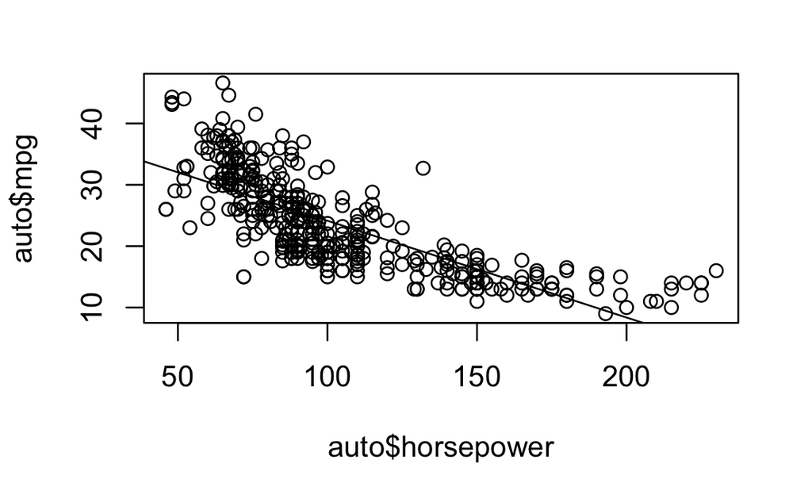

```r
plot(auto$horsepower, auto$mpg)
abline(lm)
```

## 8c

> Use the `plot()` function to produce diagnostic plots of the least squares regression fit. Comment on any problems you see with the fit.

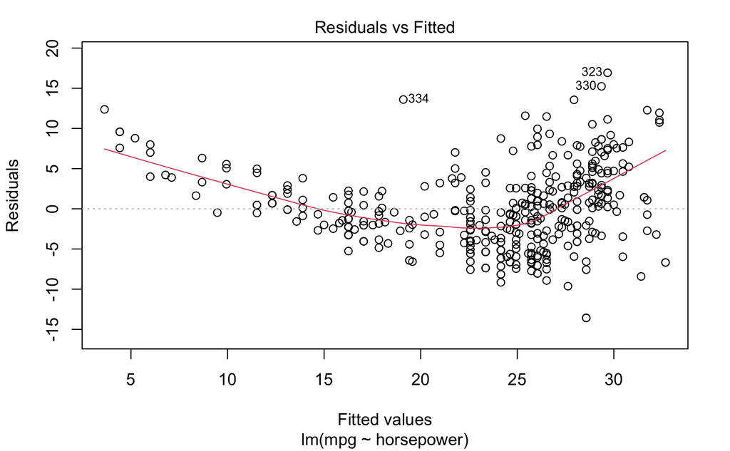

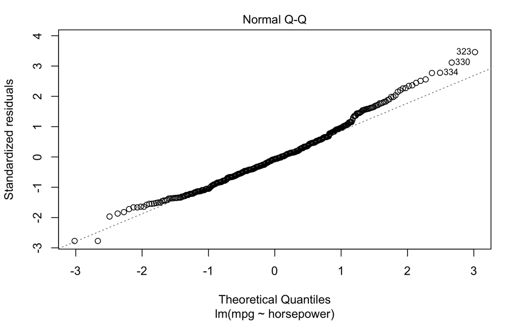

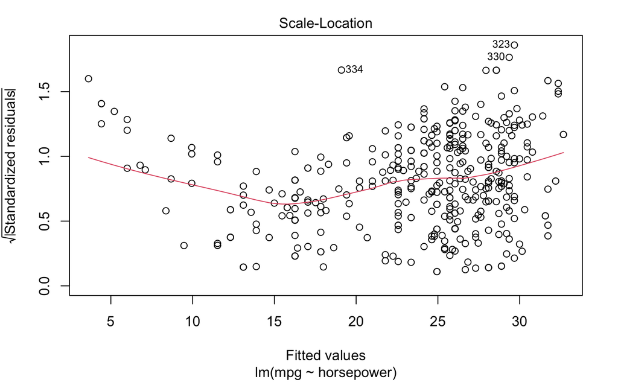

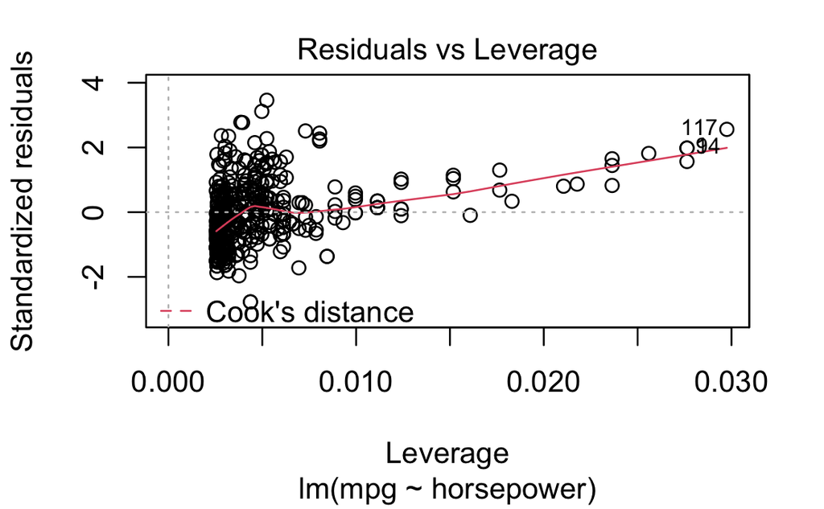

```r
plot(lm)
```

From the textbook, Figure 3.9: “*Plots of residuals versus predicted (or fitted) values for the Auto data set. In each plot, the red line is a smooth fit to the residuals, intended to make it easier to identify a trend. Left: A linear regression of `mpg` on `horsepower`. A strong pattern in the residuals indicates non-linearity in the data. Right: A linear regression of `mpg` on `horsepower` and `horsepower`. There is little pattern in the residuals.*”

# 9

> This question involves the use of multiple linear regression on the `Auto` data set.

## 9a

> Produce a scatterplot matrix which includes all of the variables in the data set.

[figure not shown]

```r
auto$name <- as.factor(auto$name)
pairs(auto)
```

## 9b

> Compute the matrix of correlations between the variables using the function `cor()`. You will need to exclude the `name` variable, which is qualitative.

```r
cor(auto[, -9])
```

```
                    mpg  cylinders displacement horsepower     weight acceleration       year     origin
mpg           1.0000000 -0.7762599   -0.8044430         NA -0.8317389    0.4222974  0.5814695  0.5636979
cylinders    -0.7762599  1.0000000    0.9509199         NA  0.8970169   -0.5040606 -0.3467172 -0.5649716
displacement -0.8044430  0.9509199    1.0000000         NA  0.9331044   -0.5441618 -0.3698041 -0.6106643
horsepower           NA         NA           NA          1         NA           NA         NA         NA
weight       -0.8317389  0.8970169    0.9331044         NA  1.0000000   -0.4195023 -0.3079004 -0.5812652
acceleration  0.4222974 -0.5040606   -0.5441618         NA -0.4195023    1.0000000  0.2829009  0.2100836
year          0.5814695 -0.3467172   -0.3698041         NA -0.3079004    0.2829009  1.0000000  0.1843141
origin        0.5636979 -0.5649716   -0.6106643         NA -0.5812652    0.2100836  0.1843141  1.0000000
```

## 9c

> Use the `lm()` function to perform a multiple linear regression with `mpg` as the response and all other variables except `name` as the predictors. Use the `summary()` function to print the results. Comment on the output. For instance:

```r
lm <- lm(mpg ~ cylinders + displacement + horsepower + weight + acceleration + year + origin, auto)
lm
```

```
Call:
lm(formula = mpg ~ cylinders + displacement + horsepower + weight +
    acceleration + year + origin, data = auto)

Coefficients:
 (Intercept)     cylinders  displacement    horsepower        weight  acceleration          year        origin
  -17.218435     -0.493376      0.019896     -0.016951     -0.006474      0.080576      0.750773      1.426140
```

```r
summary(lm)
```

```
Call:
lm(formula = mpg ~ cylinders + displacement + horsepower + weight +
    acceleration + year + origin, data = auto)

Residuals:
    Min      1Q  Median      3Q     Max
-9.5903 -2.1565 -0.1169  1.8690 13.0604

Coefficients:
               Estimate Std. Error t value Pr(>|t|)
(Intercept)  -17.218435   4.644294  -3.707  0.00024 ***
cylinders     -0.493376   0.323282  -1.526  0.12780
displacement   0.019896   0.007515   2.647  0.00844 **
horsepower    -0.016951   0.013787  -1.230  0.21963
weight        -0.006474   0.000652  -9.929  < 2e-16 ***
acceleration   0.080576   0.098845   0.815  0.41548
year           0.750773   0.050973  14.729  < 2e-16 ***
origin         1.426141   0.278136   5.127 4.67e-07 ***
---
Signif. codes:  0 ‘***’ 0.001 ‘**’ 0.01 ‘*’ 0.05 ‘.’ 0.1 ‘ ’ 1

Residual standard error: 3.328 on 384 degrees of freedom
  (5 observations deleted due to missingness)
Multiple R-squared:  0.8215,    Adjusted R-squared:  0.8182
F-statistic: 252.4 on 7 and 384 DF,  p-value: < 2.2e-16
```

### 9c i

> Is there a relationship between the predictors and the re- sponse?

There is a relationship between `mpg` and `displacement`, `weight`, `year`, and `origin`.

### 9c ii

> Which predictors appear to have a statistically significant relationship to the response?

There is a relationship between `mpg` and `displacement`, `weight`, `year`, and `origin`.

### 9c iii

> What does the coefficient for the `year` variable suggest?

This suggests that the `mpg` increases alongside the `year`. (Cars become more efficient over time).

## 9d

> Use the `plot()` function to produce diagnostic plots of the linear regression fit. Comment on any problems you see with the fit. Do the residual plots suggest any unusually large outliers? Does the leverage plot identify any observations with unusually high leverage?

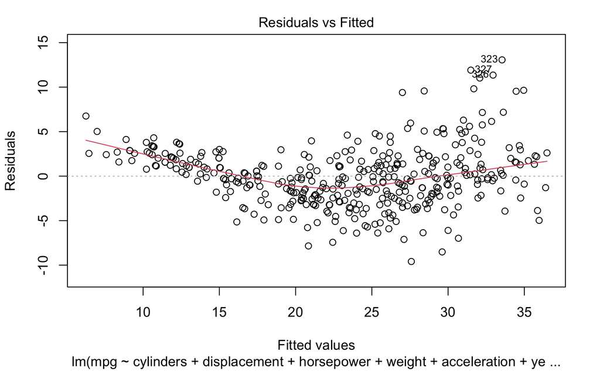

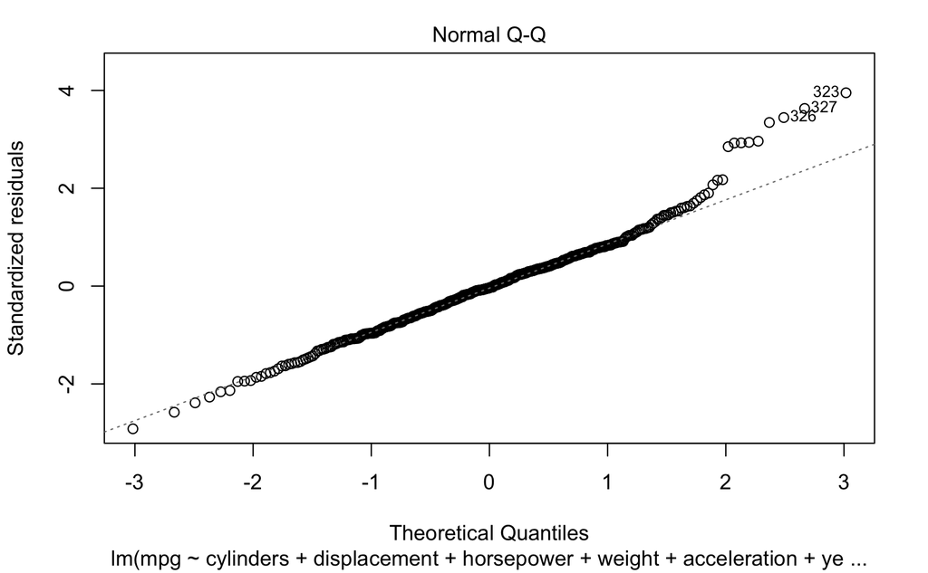

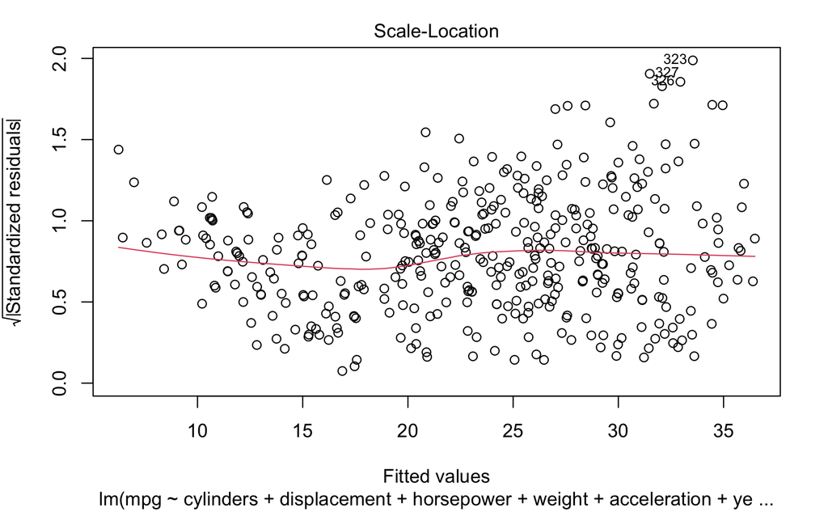

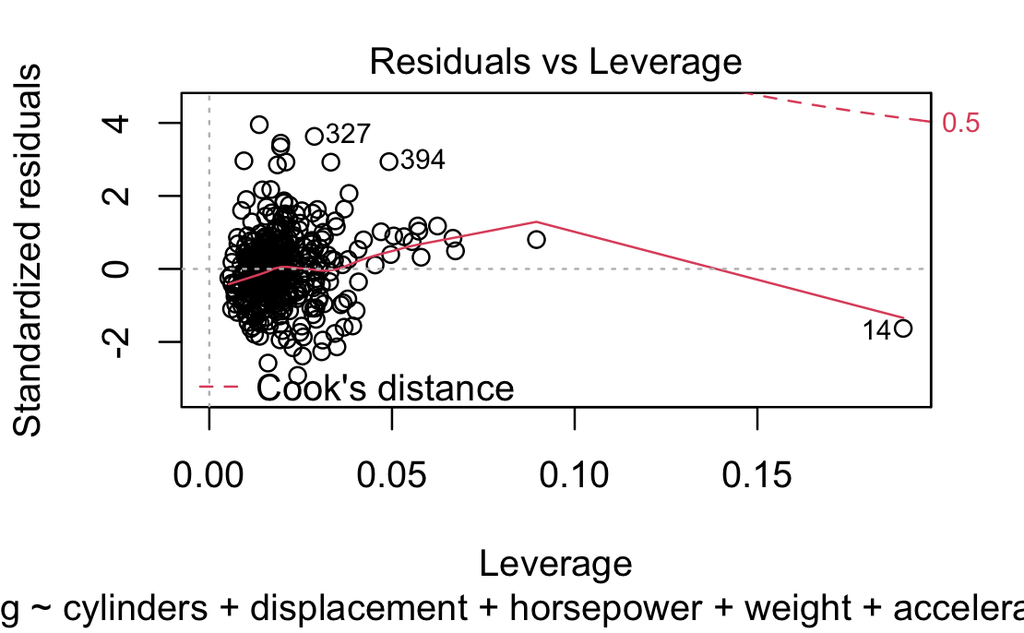

```r
plot(lm)
```

There are a decent amount of outliers among the dataset. There are a few observations with strangely high leverage.

## 9e

> Use the `*` and `:` symbols to fit linear regression models with interaction effects. Do any interactions appear to be statistically significant?

```r
summary(lm(mpg ~ cylinders * displacement + horsepower:weight, auto))
```

```
Call:
lm(formula = mpg ~ cylinders * displacement + horsepower:weight,
    data = auto)

Residuals:
     Min       1Q   Median       3Q      Max
-15.8087  -2.2841  -0.5424   2.1259  17.5877

Coefficients:
                         Estimate Std. Error t value Pr(>|t|)
(Intercept)             5.524e+01  2.384e+00  23.167  < 2e-16 ***
cylinders              -3.831e+00  5.339e-01  -7.176 3.68e-12 ***
displacement           -1.388e-01  1.511e-02  -9.184  < 2e-16 ***
cylinders:displacement  1.923e-02  2.171e-03   8.857  < 2e-16 ***
horsepower:weight      -2.231e-05  2.961e-06  -7.533 3.54e-13 ***
---
Signif. codes:  0 ‘***’ 0.001 ‘**’ 0.01 ‘*’ 0.05 ‘.’ 0.1 ‘ ’ 1

Residual standard error: 4.164 on 387 degrees of freedom
  (5 observations deleted due to missingness)
Multiple R-squared:  0.7182,    Adjusted R-squared:  0.7153
F-statistic: 246.6 on 4 and 387 DF,  p-value: < 2.2e-16
```

I guessed and it turns out that my suspicions were correct. `cylinders:diplacement` and `horsepower:weight` were significant.

## 9f

> Try a few different transformations of the variables, such as $log(X)$, $\sqrt{X}$, $X^2$. Comment on your findings.

```r
summary(lm(log(mpg) ~ cylinders^2, auto))
```

```
Call:
lm(formula = log(mpg) ~ cylinders^2, data = auto)

Residuals:
     Min       1Q   Median       3Q      Max
-0.61694 -0.12149 -0.00995  0.12358  0.62573

Coefficients:
             Estimate Std. Error t value Pr(>|t|)
(Intercept)  4.002754   0.032379  123.62   <2e-16 ***
cylinders   -0.165149   0.005664  -29.16   <2e-16 ***
---
Signif. codes:  0 ‘***’ 0.001 ‘**’ 0.01 ‘*’ 0.05 ‘.’ 0.1 ‘ ’ 1

Residual standard error: 0.1918 on 395 degrees of freedom
Multiple R-squared:  0.6828,    Adjusted R-squared:  0.682
F-statistic: 850.3 on 1 and 395 DF,  p-value: < 2.2e-16
```

```r
summary(lm(log(mpg) ~ cylinders^2 + log(horsepower)^2:sqrt(weight), auto))
```

```
Call:
lm(formula = log(mpg) ~ cylinders^2 + log(horsepower)^2:sqrt(weight),
    data = auto)

Residuals:
     Min       1Q   Median       3Q      Max
-0.47818 -0.10004 -0.00615  0.10030  0.51869

Coefficients:
                               Estimate Std. Error t value Pr(>|t|)
(Intercept)                   4.4881118  0.0421172 106.563   <2e-16 ***
cylinders                    -0.0211598  0.0107477  -1.969   0.0497 *
log(horsepower):sqrt(weight) -0.0050924  0.0003451 -14.756   <2e-16 ***
---
Signif. codes:  0 ‘***’ 0.001 ‘**’ 0.01 ‘*’ 0.05 ‘.’ 0.1 ‘ ’ 1

Residual standard error: 0.1535 on 389 degrees of freedom
  (5 observations deleted due to missingness)
Multiple R-squared:  0.7972,    Adjusted R-squared:  0.7961
F-statistic: 764.4 on 2 and 389 DF,  p-value: < 2.2e-16
```

I’m a little surprised that the regressions didn’t break as easily as I thought they would with some basic transformations.

# 10

> This question should be answered using the `Carseats` data set.

```r
carseats <- ISLR2::Carseats
```

## 10a

> Fit a multiple regression model to predict `Sales` using `Price`, `Urban`, and `US.`

```r
lm <- lm(Sales ~ Price + Urban + US, carseats)
lm
```

```
Call:
lm(formula = Sales ~ Price + Urban + US, data = carseats)

Coefficients:
(Intercept)        Price     UrbanYes        USYes
   13.04347     -0.05446     -0.02192      1.20057
```

```r
summary(lm)
```

```
Call:
lm(formula = Sales ~ Price + Urban + US, data = carseats)

Residuals:
    Min      1Q  Median      3Q     Max
-6.9206 -1.6220 -0.0564  1.5786  7.0581

Coefficients:
             Estimate Std. Error t value Pr(>|t|)
(Intercept) 13.043469   0.651012  20.036  < 2e-16 ***
Price       -0.054459   0.005242 -10.389  < 2e-16 ***
UrbanYes    -0.021916   0.271650  -0.081    0.936
USYes        1.200573   0.259042   4.635 4.86e-06 ***
---
Signif. codes:
0 ‘***’ 0.001 ‘**’ 0.01 ‘*’ 0.05 ‘.’ 0.1 ‘ ’ 1

Residual standard error: 2.472 on 396 degrees of freedom
Multiple R-squared:  0.2393,    Adjusted R-squared:  0.2335
F-statistic: 41.52 on 3 and 396 DF,  p-value: < 2.2e-16
```

## 10b

> Provide an interpretation of each coefficient in the model. Be careful—some of the variables in the model are qualitative!

## 10c

> Write out the model in equation form, being careful to handle the qualitative variables properly.